# PACTS Study

Analysis of trial results

Peter MacPherson Liverpool School of Tropical Medicine, Liverpool, UK Malawi-Liverpool-Wellcome Clinical Research Programme, Blantyre, Malawi

May 28, 2019 Table of Contents:

## 1. Backgound

Analysis of the PACTS Study trial data.

## 2. Set-up

Load all required packages for analysis.

```r
library(tidyverse)    #for data manipulation
library(pmthemes)     #for ggplot themes
library(knitr)        #for tables
library(here)         #for file nagivation
library(arsenal)      #for tables of baseline characteristics
library(rms)          #for regression modelling
library(janitor)      #for tables
```

## 3. Table 1: Baseline characteristics of participants and household members

These data are taken from table `pacts03_indexbase`.

```r
data("index_baseline", package="PACTSstudy")

table1 <- tableby(group ~ sex + age + marital + educ + employ +
                  hiv + art + tbtype + hh_size + hh_children +
                  hh_u5 + head_age + head_sex + hh_prevtb +wealth_quintile,
                  data = index_baseline, test=FALSE,
                  numeric.stats=c("medianrange"), digits=1)

kable(summary(table1))
```

|  | PACTS (N=106) | SOC (N=107) | Total (N=213) |
| --- | --- | --- | --- |
| **sex** |  |  |  |
| Female | 39 (36.8%) | 37 (34.6%) | 76 (35.7%) |
| Male | 67 (63.2%) | 70 (65.4%) | 137 (64.3%) |
| **age** |  |  |  |
| Median (Range) | 33.5 (19.0, 73.0) | 32.0 (18.0, 70.0) | 33.0 (18.0, 73.0) |
| **marital** |  |  |  |
| Living as if married | 5 (4.7%) | 5 (4.7%) | 10 (4.7%) |
| Married | 57 (53.8%) | 61 (57.0%) | 118 (55.4%) |
| Married but not living together | 3 (2.8%) | 7 (6.5%) | 10 (4.7%) |
| Polygamous marriage | 13 (12.3%) | 10 (9.3%) | 23 (10.8%) |
| Separated | 4 (3.8%) | 0 (0.0%) | 4 (1.9%) |
| Single | 7 (6.6%) | 5 (4.7%) | 12 (5.6%) |
| Widowed | 17 (16.0%) | 19 (17.8%) | 36 (16.9%) |
| **educ** |  |  |  |
| 1=No school | 3 (2.8%) | 4 (3.7%) | 7 (3.3%) |
| 2=Primary | 40 (37.7%) | 44 (41.1%) | 84 (39.4%) |
| 3=Secondary | 58 (54.7%) | 56 (52.3%) | 114 (53.5%) |
| 4=Higher | 5 (4.7%) | 3 (2.8%) | 8 (3.8%) |
| **employ** |  |  |  |
| Employed | 69 (65.1%) | 77 (72.0%) | 146 (68.5%) |
| Not employed | 37 (34.9%) | 30 (28.0%) | 67 (31.5%) |
| **hiv** |  |  |  |
| a_HIV-negative | 35 (33.0%) | 37 (34.6%) | 72 (33.8%) |
| b_HIV-positive | 62 (58.5%) | 61 (57.0%) | 123 (57.7%) |
| c_Unknown | 9 (8.5%) | 9 (8.4%) | 18 (8.5%) |
| **art** |  |  |  |
| N-Miss | 34 | 37 | 71 |
| Not on ART | 33 (45.8%) | 30 (42.9%) | 63 (44.4%) |
| On ART | 39 (54.2%) | 40 (57.1%) | 79 (55.6%) |
| **tbtype** |  |  |  |
| Smr -ve, Culture +ve | 50 (47.2%) | 43 (40.2%) | 93 (43.7%) |
| Smr +ve, Culture +ve | 56 (52.8%) | 64 (59.8%) | 120 (56.3%) |
| **hh_size** |  |  |  |
| Median (Range) | 5.0 (2.0, 19.0) | 5.0 (0.0, 11.0) | 5.0 (0.0, 19.0) |
| **hh_children** |  |  |  |
| Median (Range) | 2.0 (0.0, 7.0) | 2.0 (0.0, 8.0) | 2.0 (0.0, 8.0) |
| **hh_u5** |  |  |  |
| Median (Range) | 1.0 (0.0, 3.0) | 1.0 (0.0, 4.0) | 1.0 (0.0, 4.0) |
| **head_age** |  |  |  |
| Median (Range) | 36.5 (21.0, 80.0) | 37.0 (18.0, 77.0) | 37.0 (18.0, 80.0) |
| **head_sex** |  |  |  |
| N-Miss | 10 | 6 | 16 |
| Female | 53 (55.2%) | 57 (56.4%) | 110 (55.8%) |
| Male | 43 (44.8%) | 44 (43.6%) | 87 (44.2%) |
| **hh_prevtb** |  |  |  |
| N-Miss | 10 | 6 | 16 |
| No | 84 (87.5%) | 88 (87.1%) | 172 (87.3%) |
| Yes | 12 (12.5%) | 13 (12.9%) | 25 (12.7%) |
| **wealth_quintile** |  |  |  |
| N-Miss | 11 | 7 | 18 |
| a_Least poor | 23 (24.2%) | 16 (16.0%) | 39 (20.0%) |
| b_Less poor than average | 22 (23.2%) | 17 (17.0%) | 39 (20.0%) |
| c_Average | 19 (20.0%) | 20 (20.0%) | 39 (20.0%) |
| d_Poorer than average | 16 (16.8%) | 23 (23.0%) | 39 (20.0%) |
| e_Poorest | 15 (15.8%) | 24 (24.0%) | 39 (20.0%) |

## 4. Table 2: Baseline characteristics of household contacts

These data are taken from tables `pacts04A_hhTBscreen1` and `pacts04A_hhTBscreen2`.

```r
data("contacts_threemonths", package="PACTSstudy")

table2 <- tableby(group ~ p05age + contact_agegroup + contact_sex +
                  contact_educ,
                  data = contacts_threemonths, test=FALSE,
                  numeric.stats=c("medianrange"), digits=1)

kable(summary(table2))
```

|  | Control_soc (N=420) | Intervention_pacts (N=418) | Total (N=838) |
| --- | --- | --- | --- |
| **p05age** |  |  |  |
| Median (Range) | 13.0 (0.0, 84.0) | 16.5 (1.0, 87.0) | 14.0 (0.0, 87.0) |
| **contact_agegroup** |  |  |  |
| 0-4 | 81 (19.3%) | 67 (16.0%) | 148 (17.7%) |
| 15-24 | 66 (15.7%) | 86 (20.6%) | 152 (18.1%) |
| 25-34 | 63 (15.0%) | 64 (15.3%) | 127 (15.2%) |
| 35-44 | 31 (7.4%) | 38 (9.1%) | 69 (8.2%) |
| 45+ | 33 (7.9%) | 37 (8.9%) | 70 (8.4%) |
| 5-14 | 146 (34.8%) | 126 (30.1%) | 272 (32.5%) |
| **contact_sex** |  |  |  |
| N-Miss | 0 | 1 | 1 |
| Female | 230 (54.8%) | 220 (52.8%) | 450 (53.8%) |
| Male | 190 (45.2%) | 197 (47.2%) | 387 (46.2%) |
| **contact_educ** |  |  |  |
| N-Miss | 0 | 4 | 4 |
| 1=No school | 284 (67.6%) | 256 (61.8%) | 540 (64.7%) |
| 2=Primary | 76 (18.1%) | 75 (18.1%) | 151 (18.1%) |
| 3=Secondary | 50 (11.9%) | 68 (16.4%) | 118 (14.1%) |
| 4=Higher | 10 (2.4%) | 15 (3.6%) | 25 (3.0%) |

## 5. Primary outcome 1: Proportion of household contacts diagnosed with TB

i.e. with microbiologically confirmed TB, or taking TB treatment.

First univariate model. Note that we adjust confidence intervals for household clustering by using the sandwich estimator.

```r
data("contacts_threemonths", package="PACTSstudy")

contacts_threemonths %>%
  tabyl(m3_tb_out, group) %>%
  adorn_totals("row") %>%
  adorn_percentages("col") %>%
  adorn_pct_formatting() %>%
  adorn_ns() %>%
  kable()
```

| m3_tb_out | Control_soc | Intervention_pacts |
| --- | --- | --- |
| 0 | 99.3% (417) | 98.6% (412) |
| 1 | 0.7% (3) | 1.4% (6) |
| Total | 100.0% (420) | 100.0% (418) |

```r
set.seed(42)

up1 <- lrm(m3_tb_out ~ group, x=T, y=T, data=contacts_threemonths)
up1
```

```
## Logistic Regression Model
##
##  lrm(formula = m3_tb_out ~ group, data = contacts_threemonths,
##      x = T, y = T)
##
##                       Model Likelihood     Discrimination    Rank Discrim.
##                          Ratio Test           Indexes           Indexes
##  Obs           838    LR chi2      1.04    R2       0.011    C       0.585
##   0            829    d.f.            1    g        0.353    Dxy     0.170
##   1              9    Pr(> chi2) 0.3067    gr       1.423    gamma   0.339
##  max |deriv| 2e-11                         gp       0.004    tau-a   0.004
##                                            Brier    0.011
##
##                           Coef    S.E.   Wald Z Pr(>|Z|)
##  Intercept                -4.9345 0.5794 -8.52  <0.0001
##  group=Intervention_pacts  0.7052 0.7105  0.99  0.3209
##
```

```r
up1<-robcov(up1, cluster=contacts_threemonths$id)
kable(cbind((exp(up1$coefficients)), exp(confint.default(up1))), digits=2)
```

|  |  | 2.5 % | 97.5 % |
| --- | --- | --- | --- |
| Intercept | 0.01 | 0.00 | 0.02 |
| group=Intervention_pacts | 2.02 | 0.48 | 8.51 |

Now construct a multivariable model. We adjust for trial arm, wealth quintile, and TB type of index case.

Model internal validation is done using 1000 bootstrap replications. Note the over-optimism that this will externally validate by inspecting Somer’s Dxy statistic.

```r
#Multivariable model
mp1 <- lrm(m3_tb_out ~ group + wealth_quintile + tbtype, x=T, y=T, data=contacts_threemonths)
mp1
```

```
## Frequencies of Missing Values Due to Each Variable
##       m3_tb_out           group wealth_quintile          tbtype
##               0               0               9               0
##
## Logistic Regression Model
##
##  lrm(formula = m3_tb_out ~ group + wealth_quintile + tbtype, data = contacts_threemonths,
##      x = T, y = T)
##
##
##                       Model Likelihood     Discrimination    Rank Discrim.
##                          Ratio Test           Indexes           Indexes
##  Obs           829    LR chi2      3.16    R2       0.034    C       0.637
##   0            820    d.f.            6    g        0.676    Dxy     0.274
##   1              9    Pr(> chi2) 0.7880    gr       1.966    gamma   0.303
##  max |deriv| 1e-07                         gp       0.007    tau-a   0.006
##                                            Brier    0.011
##
##                                           Coef    S.E.   Wald Z Pr(>|Z|)
##  Intercept                                -5.3304 1.1757 -4.53  <0.0001
##  group=Intervention_pacts                  0.7797 0.7175  1.09  0.2772
##  wealth_quintile=b_Less poor than average  0.1998 1.4284  0.14  0.8887
##  wealth_quintile=c_Average                 0.1175 1.4215  0.08  0.9341
##  wealth_quintile=d_Poorer than average     1.0239 1.1645  0.88  0.3793
##  wealth_quintile=e_Poorest                 0.9605 1.1764  0.82  0.4143
##  tbtype=Smr +ve, Culture +ve              -0.4954 0.6875 -0.72  0.4711
##
```

```r
mp1<-robcov(mp1, cluster=contacts_threemonths$id)
kable(cbind((exp(mp1$coefficients)), exp(confint.default(mp1))), digits = 2)
```

|  |  | 2.5 % | 97.5 % |
| --- | --- | --- | --- |
| Intercept | 0.00 | 0.00 | 0.03 |
| group=Intervention_pacts | 2.18 | 0.60 | 7.95 |
| wealth_quintile=b_Less poor than average | 1.22 | 0.09 | 16.84 |
| wealth_quintile=c_Average | 1.12 | 0.08 | 16.05 |
| wealth_quintile=d_Poorer than average | 2.78 | 0.26 | 30.30 |
| wealth_quintile=e_Poorest | 2.61 | 0.36 | 19.06 |
| tbtype=Smr +ve, Culture +ve | 0.61 | 0.19 | 2.00 |

```r
#validate the model
validate(mp1, B=1000)
```

```
##           index.orig training    test optimism index.corrected    n
## Dxy           0.2659   0.5061  0.1780   0.3281         -0.0623 1000
## R2            0.0337   0.1091  0.0107   0.0984         -0.0647 1000
## Intercept     0.0000   0.0000 -3.5145   3.5145         -3.5145 1000
## Slope         1.0000   1.0000  0.1970   0.8030          0.1970 1000
## Emax          0.0000   0.0000  0.9217   0.9217          0.9217 1000
## D             0.0026   0.0102  0.0000   0.0102         -0.0076 1000
## U            -0.0024  -0.0024  0.0274  -0.0298          0.0274 1000
## Q             0.0050   0.0127 -0.0274   0.0401         -0.0351 1000
## B             0.0107   0.0105  0.0107  -0.0003          0.0110 1000
## g             0.6761   2.9567  0.3610   2.5958         -1.9197 1000
## gp            0.0071   0.0109  0.0035   0.0074         -0.0003 1000
```

```r
cmp1 <- calibrate(mp1, B=1000)
```

```
##
## Divergence or singularity in 2 samples
```

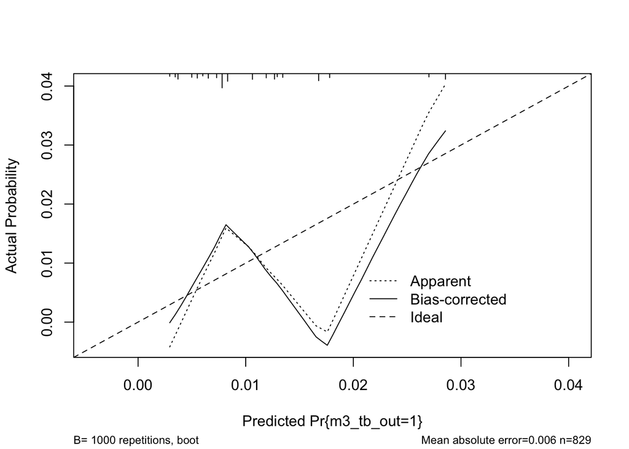

```
##
## n=829   Mean absolute error=0.006   Mean squared error=7e-05
## 0.9 Quantile of absolute error=0.019
```

```r
plot(cmp1)
```

## 6. Primary outcome 2: Proportion of Under 5s who initiated IPT.

First univariate model. Note that we adjust confidence intervals for household clustering by using the sandwich estimator.

```r
data("under5s_3m", package="PACTSstudy")

under5s_3m %>%
  tabyl(iptrx, group) %>%
  adorn_totals("row") %>%
  adorn_percentages("col") %>%
  adorn_pct_formatting() %>%
  adorn_ns() %>%
  kable()
```

| iptrx | Control_soc | Intervention_pacts |
| --- | --- | --- |
| 0 | 58.6% (51) | 40.7% (33) |
| 1 | 41.4% (36) | 58.0% (47) |
| NA | 0.0% (0) | 1.2% (1) |
| Total | 100.0% (87) | 100.0% (81) |

```r
set.seed(42)

up2 <- lrm(iptrx ~ group, x=T, y=T, data=under5s_3m)
up2
```

```
## Frequencies of Missing Values Due to Each Variable
## iptrx group
##     1     0
##
## Logistic Regression Model
##
##  lrm(formula = iptrx ~ group, data = under5s_3m, x = T, y = T)
##
##
##                       Model Likelihood     Discrimination    Rank Discrim.
##                          Ratio Test           Indexes           Indexes
##  Obs           167    LR chi2      5.06    R2       0.040    C       0.587
##   0             84    d.f.            1    g        0.352    Dxy     0.173
##   1             83    Pr(> chi2) 0.0245    gr       1.423    gamma   0.337
##  max |deriv| 2e-12                         gp       0.087    tau-a   0.087
##                                            Brier    0.242
##
##                           Coef    S.E.   Wald Z Pr(>|Z|)
##  Intercept                -0.3483 0.2177 -1.60  0.1096
##  group=Intervention_pacts  0.7019 0.3146  2.23  0.0257
##
```

```r
up2<-robcov(up2, cluster=under5s_3m$id)
kable(cbind((exp(up2$coefficients)), exp(confint.default(up2))), digits=2)
```

|  |  | 2.5 % | 97.5 % |
| --- | --- | --- | --- |
| Intercept | 0.71 | 0.42 | 1.17 |
| group=Intervention_pacts | 2.02 | 0.96 | 4.24 |

Now construct a multivariable model. We adjust for trial arm, wealth quintile, and TB type of index case.

Model internal validation is done using 1000 bootstrap replications. Note the over-optimism that this will externally validate by inspecting Somer’s Dxy statistic.

```r
mp2 <- lrm(iptrx ~ group + wealth_quintile + tbtype, x=T, y=T, data=under5s_3m)
mp2
```

```
## Frequencies of Missing Values Due to Each Variable
##           iptrx           group wealth_quintile          tbtype
##               1               0               2               0
##
## Logistic Regression Model
##
##  lrm(formula = iptrx ~ group + wealth_quintile + tbtype, data = under5s_3m,
##      x = T, y = T)
##
##
##                       Model Likelihood     Discrimination    Rank Discrim.
##                          Ratio Test           Indexes           Indexes
##  Obs           165    LR chi2     22.04    R2       0.167    C       0.679
##   0             84    d.f.            6    g        0.880    Dxy     0.359
##   1             81    Pr(> chi2) 0.0012    gr       2.410    gamma   0.381
##  max |deriv| 2e-08                         gp       0.196    tau-a   0.180
##                                            Brier    0.218
##
##                                           Coef    S.E.   Wald Z Pr(>|Z|)
##  Intercept                                 0.9947 0.6920  1.44  0.1506
##  group=Intervention_pacts                  0.5840 0.3432  1.70  0.0888
##  wealth_quintile=b_Less poor than average -0.7314 0.7880 -0.93  0.3533
##  wealth_quintile=c_Average                -1.7787 0.7461 -2.38  0.0171
##  wealth_quintile=d_Poorer than average    -1.9262 0.7343 -2.62  0.0087
##  wealth_quintile=e_Poorest                -2.0832 0.7204 -2.89  0.0038
##  tbtype=Smr +ve, Culture +ve               0.4421 0.3584  1.23  0.2174
##
```

```r
mp2<-robcov(mp2, cluster=under5s_3m$id)
kable(cbind((exp(mp2$coefficients)), exp(confint.default(mp2))), digits = 2)
```

|  |  | 2.5 % | 97.5 % |
| --- | --- | --- | --- |
| Intercept | 2.70 | 0.67 | 10.85 |
| group=Intervention_pacts | 1.79 | 0.80 | 4.02 |
| wealth_quintile=b_Less poor than average | 0.48 | 0.09 | 2.45 |
| wealth_quintile=c_Average | 0.17 | 0.03 | 0.82 |
| wealth_quintile=d_Poorer than average | 0.15 | 0.03 | 0.70 |
| wealth_quintile=e_Poorest | 0.12 | 0.03 | 0.59 |
| tbtype=Smr +ve, Culture +ve | 1.56 | 0.67 | 3.63 |

```r
#validate the model
validate(mp2, B=1000)
```

```
##           index.orig training    test optimism index.corrected    n
## Dxy           0.3586   0.4268  0.3405   0.0863          0.2723 1000
## R2            0.1667   0.2078  0.1343   0.0735          0.0932 1000
## Intercept     0.0000   0.0000 -0.0250   0.0250         -0.0250 1000
## Slope         1.0000   1.0000  0.7634   0.2366          0.7634 1000
## Emax          0.0000   0.0000  0.0643   0.0643          0.0643 1000
## D             0.1275   0.1645  0.1003   0.0643          0.0632 1000
## U            -0.0121  -0.0121  0.0174  -0.0295          0.0174 1000
## Q             0.1396   0.1767  0.0829   0.0938          0.0458 1000
## B             0.2181   0.2091  0.2275  -0.0184          0.2366 1000
## g             0.8796   1.0683  0.7664   0.3020          0.5776 1000
## gp            0.1963   0.2171  0.1743   0.0427          0.1536 1000
```

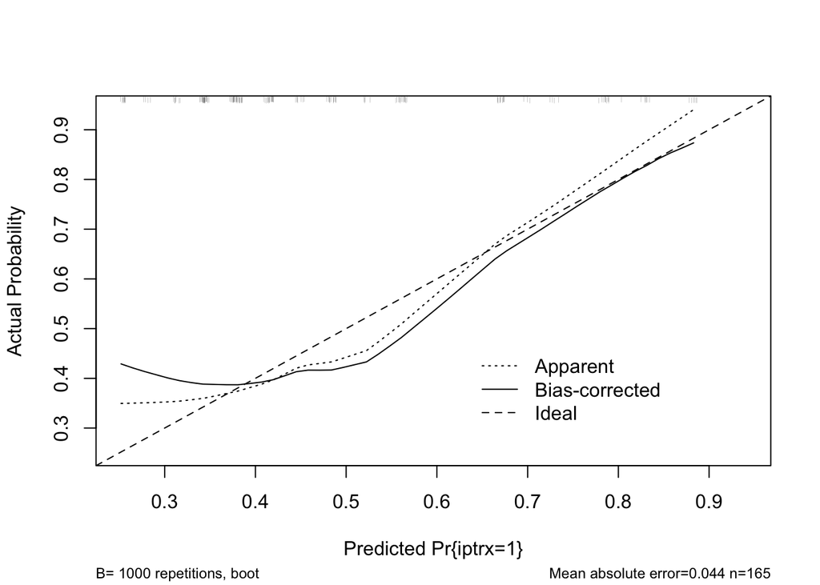

```
##
## n=165   Mean absolute error=0.044   Mean squared error=0.00388
## 0.9 Quantile of absolute error=0.087
```

```r
cmp2 <- calibrate(mp2, B=1000)

plot(cmp2)
```

## 7. Secondary outcome 1: Proportion of Under 5s who completed IPT within 9 months.

First univariate model. Note that we adjust confidence intervals for household clustering by using the sandwich estimator.

```r
data("nine_month", package="PACTSstudy")

nine_month %>%
  tabyl(ipt9comp2, arm2) %>%
  adorn_totals("row") %>%
  adorn_percentages("col") %>%
  adorn_pct_formatting() %>%
  adorn_ns() %>%
  kable()
```

| ipt9comp2 | 0 | 1 |
| --- | --- | --- |
| 0 | 44.4% (59) | 36.1% (48) |
| 1 | 22.6% (30) | 29.3% (39) |
| NA | 33.1% (44) | 34.6% (46) |
| Total | 100.0% (133) | 100.0% (133) |

```r
set.seed(42)

us1 <- lrm(ipt9comp2 ~ arm2, x=T, y=T, data=nine_month)
us1
```

```
## Frequencies of Missing Values Due to Each Variable
## ipt9comp2      arm2
##        90         0
##
## Logistic Regression Model
##
##  lrm(formula = ipt9comp2 ~ arm2, data = nine_month, x = T, y = T)
##
##
##                       Model Likelihood     Discrimination    Rank Discrim.
##                          Ratio Test           Indexes           Indexes
##  Obs           176    LR chi2      2.29    R2       0.017    C       0.558
##   0            107    d.f.            1    g        0.236    Dxy     0.117
##   1             69    Pr(> chi2) 0.1304    gr       1.266    gamma   0.230
##  max |deriv| 2e-10                         gp       0.056    tau-a   0.056
##                                            Brier    0.235
##
##            Coef    S.E.   Wald Z Pr(>|Z|)
##  Intercept -0.6763 0.2242 -3.02  0.0026
##  arm2       0.4687 0.3111  1.51  0.1319
##
```

```r
us1<-robcov(us1, cluster=nine_month$id)
kable(cbind((exp(us1$coefficients)), exp(confint.default(us1))), digits=2)
```

|  |  | 2.5 % | 97.5 % |
| --- | --- | --- | --- |
| Intercept | 0.51 | 0.30 | 0.86 |
| arm2 | 1.60 | 0.77 | 3.33 |

Now construct a multivariable model. We adjust for trial arm, wealth quintile, and TB type of index case.

Model internal validation is done using 1000 bootstrap replications. Note the over-optimism that this will externally validate by inspecting Somer’s Dxy statistic.

```r
#Multivariable model
ms1 <- lrm(ipt9comp2 ~ arm2 + wealth_quintile + smear, x=T, y=T, data=nine_month)
ms1
```

```
## Frequencies of Missing Values Due to Each Variable
##       ipt9comp2            arm2 wealth_quintile           smear
##              90               0              17               3
##
## Logistic Regression Model
##
##  lrm(formula = ipt9comp2 ~ arm2 + wealth_quintile + smear, data = nine_month,
##      x = T, y = T)
##
##
##                       Model Likelihood     Discrimination    Rank Discrim.
##                          Ratio Test           Indexes           Indexes
##  Obs           176    LR chi2     16.36    R2       0.120    C       0.659
##   0            107    d.f.            6    g        0.663    Dxy     0.318
##   1             69    Pr(> chi2) 0.0120    gr       1.940    gamma   0.336
##  max |deriv| 4e-13                         gp       0.149    tau-a   0.152
##                                            Brier    0.216
##
##                    Coef    S.E.   Wald Z Pr(>|Z|)
##  Intercept         -1.1067 0.3825 -2.89  0.0038
##  arm2               0.2721 0.3297  0.83  0.4092
##  wealth_quintile=1  0.3879 0.4478  0.87  0.3864
##  wealth_quintile=2  0.5518 0.4758  1.16  0.2462
##  wealth_quintile=3  0.7880 0.5000  1.58  0.1151
##  wealth_quintile=4  2.1804 0.6592  3.31  0.0009
##  smear             -0.0614 0.3398 -0.18  0.8566
##
```

```r
ms1<-robcov(ms1, cluster=nine_month$id)
kable(cbind((exp(ms1$coefficients)), exp(confint.default(ms1))), digits = 2)
```

|  |  | 2.5 % | 97.5 % |
| --- | --- | --- | --- |
| Intercept | 0.33 | 0.12 | 0.91 |
| arm2 | 1.31 | 0.61 | 2.85 |
| wealth_quintile=1 | 1.47 | 0.50 | 4.38 |
| wealth_quintile=2 | 1.74 | 0.58 | 5.18 |
| wealth_quintile=3 | 2.20 | 0.66 | 7.31 |
| wealth_quintile=4 | 8.85 | 2.19 | 35.81 |
| smear | 0.94 | 0.43 | 2.06 |

```r
#validate the model
validate(ms1, B=1000)
```

```
##           index.orig training    test optimism index.corrected    n
## Dxy           0.3179   0.3690  0.2597   0.1094          0.2085 1000
## R2            0.1203   0.1609  0.0924   0.0685          0.0517 1000
## Intercept     0.0000   0.0000 -0.1157   0.1157         -0.1157 1000
## Slope         1.0000   1.0000  0.7346   0.2654          0.7346 1000
## Emax          0.0000   0.0000  0.0894   0.0894          0.0894 1000
## D             0.0872   0.1216  0.0650   0.0565          0.0307 1000
## U            -0.0114  -0.0114  0.0166  -0.0279          0.0166 1000
## Q             0.0986   0.1329  0.0485   0.0845          0.0142 1000
## B             0.2161   0.2073  0.2251  -0.0179          0.2340 1000
## g             0.6625   0.8394  0.5818   0.2576          0.4049 1000
## gp            0.1486   0.1750  0.1332   0.0418          0.1067 1000
```

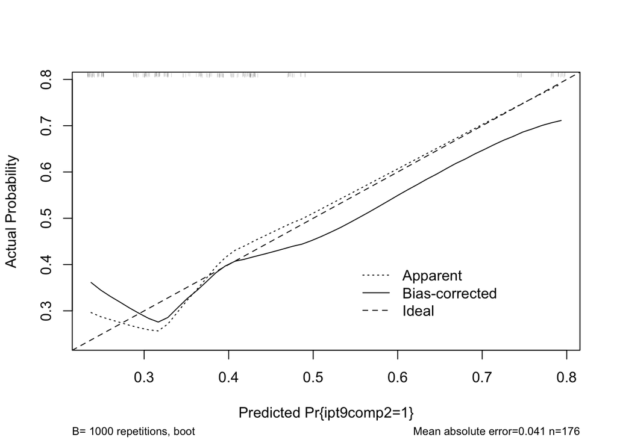

```
##
## n=176   Mean absolute error=0.041   Mean squared error=0.00326
## 0.9 Quantile of absolute error=0.097
```

```r
cms1 <- calibrate(ms1, B=1000)

plot(cms1)
```

## 8. Secondary outcome 2: Proportion of household contacts with TB symptoms at 3 months.

First univariate model. Note that we adjust confidence intervals for household clustering by using the sandwich estimator.

```r
data("contacts_threemonths", package="PACTSstudy")

contacts_threemonths %>%
  tabyl(sx_3m, group) %>%
  adorn_totals("row") %>%
  adorn_percentages("col") %>%
  adorn_pct_formatting() %>%
  adorn_ns() %>%
  kable()
```

| sx_3m | Control_soc | Intervention_pacts |
| --- | --- | --- |
| 0 | 84.0% (353) | 88.8% (371) |
| 1 | 15.7% (66) | 11.0% (46) |
| NA | 0.2% (1) | 0.2% (1) |
| Total | 100.0% (420) | 100.0% (418) |

```r
set.seed(42)

us2 <- lrm(sx_3m ~ group, x=T, y=T, data=contacts_threemonths)
us2
```

```
## Frequencies of Missing Values Due to Each Variable
## sx_3m group
##     2     0
##
## Logistic Regression Model
##
##  lrm(formula = sx_3m ~ group, data = contacts_threemonths, x = T,
##      y = T)
##
##
##                       Model Likelihood     Discrimination    Rank Discrim.
##                          Ratio Test           Indexes           Indexes
##  Obs           836    LR chi2      4.03    R2       0.009    C       0.551
##   0            724    d.f.            1    g        0.206    Dxy     0.102
##   1            112    Pr(> chi2) 0.0446    gr       1.228    gamma   0.203
##  max |deriv| 3e-07                         gp       0.024    tau-a   0.024
##                                            Brier    0.115
##
##                           Coef    S.E.   Wald Z Pr(>|Z|)
##  Intercept                -1.6768 0.1341 -12.50 <0.0001
##  group=Intervention_pacts -0.4107 0.2060  -1.99 0.0461
##
```

```r
us2<-robcov(us2, cluster=contacts_threemonths$id)
kable(cbind((exp(us2$coefficients)), exp(confint.default(us2))), digits=2)
```

|  |  | 2.5 % | 97.5 % |
| --- | --- | --- | --- |
| Intercept | 0.19 | 0.13 | 0.27 |
| group=Intervention_pacts | 0.66 | 0.39 | 1.12 |

Model internal validation is done using 1000 bootstrap replications. Note the over-optimism that this will externally validate by inspecting Somer’s Dxy statistic.

```r
#Multivariable model
ms2 <- lrm(sx_3m ~ group + wealth_quintile + tbtype, x=T, y=T, data=contacts_threemonths)
ms2
```

```
## Frequencies of Missing Values Due to Each Variable
##           sx_3m           group wealth_quintile          tbtype
##               2               0               9               0
##
## Logistic Regression Model
##
##  lrm(formula = sx_3m ~ group + wealth_quintile + tbtype, data = contacts_threemonths,
##      x = T, y = T)
##
##
##                       Model Likelihood     Discrimination    Rank Discrim.
##                          Ratio Test           Indexes           Indexes
##  Obs           827    LR chi2     14.07    R2       0.031    C       0.597
##   0            716    d.f.            6    g        0.447    Dxy     0.194
##   1            111    Pr(> chi2) 0.0289    gr       1.564    gamma   0.206
##  max |deriv| 6e-09                         gp       0.049    tau-a   0.045
##                                            Brier    0.114
##
##                                           Coef    S.E.   Wald Z Pr(>|Z|)
##  Intercept                                -1.5994 0.2838 -5.64  <0.0001
##  group=Intervention_pacts                 -0.4214 0.2102 -2.00  0.0450
##  wealth_quintile=b_Less poor than average  0.3463 0.3275  1.06  0.2904
##  wealth_quintile=c_Average                -0.0720 0.3464 -0.21  0.8354
##  wealth_quintile=d_Poorer than average    -0.7408 0.3717 -1.99  0.0463
##  wealth_quintile=e_Poorest                -0.0459 0.3160 -0.15  0.8845
##  tbtype=Smr +ve, Culture +ve               0.0302 0.2121  0.14  0.8869
##
```

```r
ms2<-robcov(ms2, cluster=contacts_threemonths$id)
kable(cbind((exp(ms2$coefficients)), exp(confint.default(ms2))), digits = 2)
```

|  |  | 2.5 % | 97.5 % |
| --- | --- | --- | --- |
| Intercept | 0.20 | 0.10 | 0.42 |
| group=Intervention_pacts | 0.66 | 0.39 | 1.10 |
| wealth_quintile=b_Less poor than average | 1.41 | 0.62 | 3.23 |
| wealth_quintile=c_Average | 0.93 | 0.39 | 2.23 |
| wealth_quintile=d_Poorer than average | 0.48 | 0.19 | 1.21 |
| wealth_quintile=e_Poorest | 0.96 | 0.42 | 2.19 |
| tbtype=Smr +ve, Culture +ve | 1.03 | 0.61 | 1.74 |

```r
#validate the model
validate(ms2, B=1000)
```

```
##           index.orig training    test optimism index.corrected    n
## Dxy           0.1942   0.2437  0.1731   0.0706          0.1236 1000
## R2            0.0309   0.0446  0.0228   0.0218          0.0091 1000
## Intercept     0.0000   0.0000 -0.4814   0.4814         -0.4814 1000
## Slope         1.0000   1.0000  0.7308   0.2692          0.7308 1000
## Emax          0.0000   0.0000  0.1709   0.1709          0.1709 1000
## D             0.0158   0.0234  0.0113   0.0121          0.0037 1000
## U            -0.0024  -0.0024  0.0019  -0.0043          0.0019 1000
## Q             0.0182   0.0258  0.0094   0.0164          0.0018 1000
## B             0.1144   0.1131  0.1155  -0.0024          0.1168 1000
## g             0.4472   0.5405  0.3793   0.1613          0.2859 1000
## gp            0.0487   0.0581  0.0423   0.0158          0.0329 1000
```

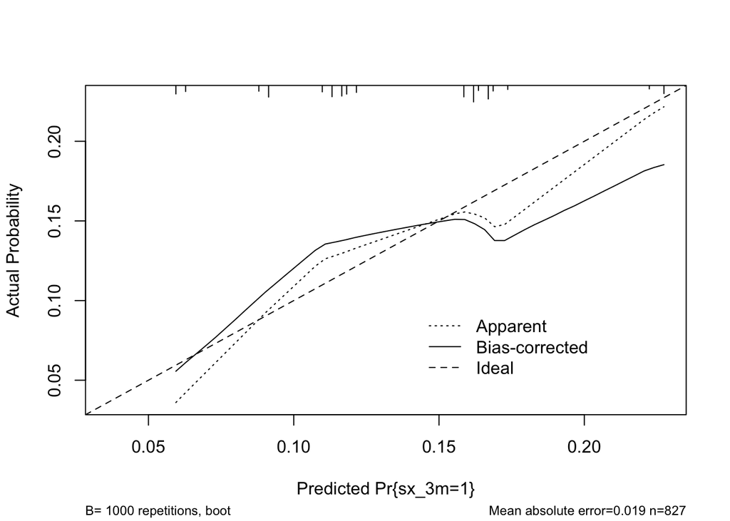

```
##
## n=827   Mean absolute error=0.019   Mean squared error=0.00045
## 0.9 Quantile of absolute error=0.035
```

```r
cms2 <- calibrate(ms2, B=1000)

plot(cms2)
```

## 9. Secondary outcome 3: Proportion of household contacts with micro-confirmed TB at 3 months.

First univariate model. Note that we adjust confidence intervals for household clustering by using the sandwich estimator.

```r
data("contacts_threemonths", package="PACTSstudy")

contacts_threemonths %>%
  tabyl(s3_micro_confirmed, group) %>%
  adorn_totals("row") %>%
  adorn_percentages("col") %>%
  adorn_pct_formatting() %>%
  adorn_ns() %>%
  kable()
```

| s3_micro_confirmed | Control_soc | Intervention_pacts |
| --- | --- | --- |
| 0 | 100.0% (420) | 99.3% (415) |
| 1 | 0.0% (0) | 0.7% (3) |
| Total | 100.0% (420) | 100.0% (418) |

```r
set.seed(42)

us3 <- lrm(s3_micro_confirmed ~ group, x=T, y=T, data=contacts_threemonths)
us3
```

```
## Logistic Regression Model
##
##  lrm(formula = s3_micro_confirmed ~ group, data = contacts_threemonths,
##      x = T, y = T)
##
##                       Model Likelihood     Discrimination    Rank Discrim.
##                          Ratio Test           Indexes           Indexes
##  Obs           838    LR chi2      4.18    R2       0.107    C       0.751
##   0            835    d.f.            1    g        3.857    Dxy     0.503
##   1              3    Pr(> chi2) 0.0409    gr      47.323    gamma   1.000
##  max |deriv| 0.001                         gp       0.004    tau-a   0.004
##                                            Brier    0.004
##
##                           Coef     S.E.    Wald Z Pr(>|Z|)
##  Intercept                -12.6345 27.0347 -0.47  0.6403
##  group=Intervention_pacts   7.7048 27.0409  0.28  0.7757
##
```

```r
us3<-robcov(us3, cluster=contacts_threemonths$id)
kable(cbind((exp(us3$coefficients)), exp(confint.default(us3))), digits=2)
```

|  |  | 2.5 % | 97.5 % |
| --- | --- | --- | --- |
| Intercept | 0.00 | 0.00 | 0.00 |
| group=Intervention_pacts | 2219.02 | 710.17 | 6933.61 |

Because there are so few events (n=3 in total), I don’t think it makes sense to do multivariable analysis). But here we go anyways…

Model internal validation is done using 1000 bootstrap replications. Note the over-optimism that this will externally validate by inspecting Somer’s Dxy statistic.

```r
#Multivariable model
ms3 <- lrm(s3_micro_confirmed ~ group + wealth_quintile + tbtype, x=T, y=T, data=contacts_threemonths)
ms3
```

```
## Frequencies of Missing Values Due to Each Variable
## s3_micro_confirmed              group    wealth_quintile
##                  0                  0                  9
##             tbtype
##                  0
##
## Logistic Regression Model
##
##  lrm(formula = s3_micro_confirmed ~ group + wealth_quintile +
##      tbtype, data = contacts_threemonths, x = T, y = T)
##
##
##                       Model Likelihood     Discrimination    Rank Discrim.
##                          Ratio Test           Indexes           Indexes
##  Obs           829    LR chi2      8.03    R2       0.206    C       0.892
##   0            826    d.f.            6    g        6.598    Dxy     0.784
##   1              3    Pr(> chi2) 0.2361    gr     733.316    gamma   0.828
##  max |deriv| 0.002                         gp       0.006    tau-a   0.006
##                                            Brier    0.004
##
##                                           Coef     S.E.    Wald Z Pr(>|Z|)
##  Intercept                                -12.2138 34.7470 -0.35  0.7252
##  group=Intervention_pacts                   8.0131 34.7383  0.23  0.8176
##  wealth_quintile=b_Less poor than average   0.3525  1.4410  0.24  0.8067
##  wealth_quintile=c_Average                  0.2495  1.4250  0.18  0.8610
##  wealth_quintile=d_Poorer than average     -7.8115 50.5873 -0.15  0.8773
##  wealth_quintile=e_Poorest                 -7.5692 47.9427 -0.16  0.8746
##  tbtype=Smr +ve, Culture +ve               -0.8219  1.2474 -0.66  0.5100
##
```

```r
ms3<-robcov(ms3, cluster=contacts_threemonths$id)
kable(cbind((exp(ms3$coefficients)), exp(confint.default(ms3))), digits = 2)
```

|  |  | 2.5 % | 97.5 % |
| --- | --- | --- | --- |
| Intercept | 0.00 | 0.00 | 0.00 |
| group=Intervention_pacts | 3020.27 | 935.99 | 9745.90 |
| wealth_quintile=b_Less poor than average | 1.42 | 0.13 | 16.17 |
| wealth_quintile=c_Average | 1.28 | 0.09 | 17.43 |
| wealth_quintile=d_Poorer than average | 0.00 | 0.00 | 0.00 |
| wealth_quintile=e_Poorest | 0.00 | 0.00 | 0.00 |
| tbtype=Smr +ve, Culture +ve | 0.44 | 0.06 | 3.49 |

```r
#validate the model
validate(ms3, B=1000)
```

```
##
## Divergence or singularity in 39 samples
```

```
##           index.orig training    test optimism index.corrected   n
## Dxy           0.7841   0.8739  0.5512   0.3227          0.4614 961
## R2            0.2060   0.3123  0.1154   0.1969          0.0091 961
## Intercept     0.0000   0.0000 -3.0075   3.0075         -3.0075 961
## Slope         1.0000   1.0000  0.3135   0.6865          0.3135 961
## Emax          0.0000   0.0000  0.8424   0.8424          0.8424 961
## D             0.0085   0.0132  0.0042   0.0090         -0.0005 961
## U            -0.0024  -0.0024  0.0214  -0.0238          0.0214 961
## Q             0.0109   0.0156 -0.0172   0.0328         -0.0219 961
## B             0.0036   0.0037  0.0036   0.0001          0.0035 961
## g             6.5976   7.1923  2.1956   4.9967          1.6009 961
## gp            0.0056   0.0065  0.0043   0.0022          0.0034 961
```

```r
cms3 <- calibrate(ms3, B=1000)
```

```
##
## Divergence or singularity in 54 samples
```

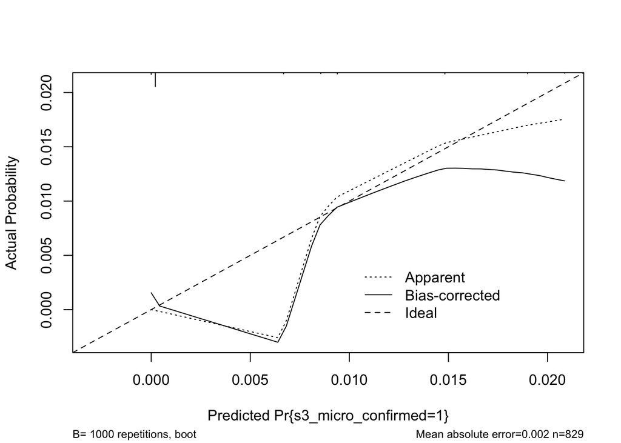

```
##
## n=829   Mean absolute error=0.002   Mean squared error=1e-05
## 0.9 Quantile of absolute error=0.006
```

```r
plot(cms3)
```

## 10. Secondary outcome 4: Proportion of households where at least one household contact was investigated by either “sputum tests”, or chest x-ray.

```r
data("household", package="PACTSstudy")

household <- household %>%
  mutate(arm2 = case_when(group=="PACTS" ~ "Intervention_PACTS",
                          group=="SOC" ~ "Control_SOC"))

household %>%
  tabyl(any_screen3m, arm2) %>%
  adorn_totals("row") %>%
  adorn_percentages("col") %>%
  adorn_pct_formatting() %>%
  adorn_ns() %>%
  kable()
```

| any_screen3m | Control_SOC | Intervention_PACTS |
| --- | --- | --- |
| 0 | 90.1% (91) | 79.2% (76) |
| 1 | 9.9% (10) | 20.8% (20) |
| Total | 100.0% (101) | 100.0% (96) |

```r
set.seed(42)

us4 <- lrm(any_screen3m ~ arm2, x=T, y=T, data=household)
us4
```

```
## Logistic Regression Model
##
##  lrm(formula = any_screen3m ~ arm2, data = household, x = T, y = T)
##
##                       Model Likelihood     Discrimination    Rank Discrim.
##                          Ratio Test           Indexes           Indexes
##  Obs           197    LR chi2      4.62    R2       0.040    C       0.606
##   0            167    d.f.            1    g        0.439    Dxy     0.212
##   1             30    Pr(> chi2) 0.0316    gr       1.551    gamma   0.411
##  max |deriv| 2e-11                         gp       0.055    tau-a   0.055
##                                            Brier    0.126
##
##                          Coef    S.E.   Wald Z Pr(>|Z|)
##  Intercept               -2.2083 0.3332 -6.63  <0.0001
##  arm2=Intervention_PACTS  0.8733 0.4173  2.09  0.0364
##
```

```r
kable(cbind((exp(us4$coefficients)), exp(confint.default(us4))), digits=2)
```

|  |  | 2.5 % | 97.5 % |
| --- | --- | --- | --- |
| Intercept | 0.11 | 0.06 | 0.21 |
| arm2=Intervention_PACTS | 2.39 | 1.06 | 5.43 |

```r
ms4 <- lrm(any_screen3m ~ arm2 + wealth_quintile + tbtype, x=T, y=T, data=household)
ms4
```

```
## Frequencies of Missing Values Due to Each Variable
##    any_screen3m            arm2 wealth_quintile          tbtype
##               0               0               2               0
##
## Logistic Regression Model
##
##  lrm(formula = any_screen3m ~ arm2 + wealth_quintile + tbtype,
##      data = household, x = T, y = T)
##
##
##                       Model Likelihood     Discrimination    Rank Discrim.
##                          Ratio Test           Indexes           Indexes
##  Obs           195    LR chi2      6.16    R2       0.054    C       0.638
##   0            165    d.f.            6    g        0.585    Dxy     0.277
##   1             30    Pr(> chi2) 0.4060    gr       1.795    gamma   0.292
##  max |deriv| 2e-10                         gp       0.073    tau-a   0.072
##                                            Brier    0.126
##
##                                           Coef    S.E.   Wald Z Pr(>|Z|)
##  Intercept                                -2.7252 0.6265 -4.35  <0.0001
##  arm2=Intervention_PACTS                   0.9496 0.4272  2.22  0.0262
##  wealth_quintile=b_Less poor than average  0.1646 0.6666  0.25  0.8049
##  wealth_quintile=c_Average                 0.4465 0.6489  0.69  0.4914
##  wealth_quintile=d_Poorer than average     0.3434 0.6681  0.51  0.6072
##  wealth_quintile=e_Poorest                 0.3262 0.6738  0.48  0.6283
##  tbtype=Smr +ve, Culture +ve               0.3762 0.4223  0.89  0.3730
##
```

```r
kable(cbind((exp(ms4$coefficients)), exp(confint.default(ms4))), digits=2)
```

|  |  | 2.5 % | 97.5 % |
| --- | --- | --- | --- |
| Intercept | 0.07 | 0.02 | 0.22 |
| arm2=Intervention_PACTS | 2.58 | 1.12 | 5.97 |
| wealth_quintile=b_Less poor than average | 1.18 | 0.32 | 4.35 |
| wealth_quintile=c_Average | 1.56 | 0.44 | 5.58 |
| wealth_quintile=d_Poorer than average | 1.41 | 0.38 | 5.22 |
| wealth_quintile=e_Poorest | 1.39 | 0.37 | 5.19 |
| tbtype=Smr +ve, Culture +ve | 1.46 | 0.64 | 3.33 |

## 11. Reproducibility

This reproduction of the analysis was run by:

| keyName | value |
| --- | --- |
| sysname | Darwin |
| release | 18.6.0 |
| version | Darwin Kernel Version 18.6.0: Thu Apr 25 23:16:27 PDT 2019; root:xnu-4903.261.4~2/RELEASE_X86_64 |
| nodename | petermacphersons-MacBook-Pro.local |
| machine | x86_64 |
| login | peter.macpherson |
| user | peter.macpherson |
| effective_user | peter.macpherson |

Analysis was run at **2019-05-28 19:02:55**, and using the following Session Info:

```
R version 3.6.0 (2019-04-26)
Platform: x86_64-apple-darwin15.6.0 (64-bit)
Running under: macOS Mojave 10.14.5

Matrix products: default
BLAS:   /Library/Frameworks/R.framework/Versions/3.6/Resources/lib/libRblas.0.dylib
LAPACK: /Library/Frameworks/R.framework/Versions/3.6/Resources/lib/libRlapack.dylib

locale:
[1] en_GB.UTF-8/en_GB.UTF-8/en_GB.UTF-8/C/en_GB.UTF-8/en_GB.UTF-8

attached base packages:
[1] stats     graphics  grDevices utils     datasets  methods   base

other attached packages:
 [1] janitor_1.2.0       rms_5.1-3.1         SparseM_1.77
 [4] Hmisc_4.2-0         Formula_1.2-3       survival_2.44-1.1
 [7] lattice_0.20-38     arsenal_3.1.0       here_0.1
[10] knitr_1.23          pmthemes_0.0.0.9000 forcats_0.4.0
[13] stringr_1.4.0       dplyr_0.8.1         purrr_0.3.2
[16] readr_1.3.1         tidyr_0.8.3         tibble_2.1.1
[19] ggplot2_3.1.1       tidyverse_1.2.1

loaded via a namespace (and not attached):
 [1] httr_1.4.0          jsonlite_1.6        splines_3.6.0
 [4] modelr_0.1.4        assertthat_0.2.1    highr_0.8
 [7] latticeExtra_0.6-28 cellranger_1.1.0    yaml_2.2.0
[10] pillar_1.4.0        backports_1.1.4     quantreg_5.38
[13] glue_1.3.1          digest_0.6.19       RColorBrewer_1.1-2
[16] checkmate_1.9.3     rvest_0.3.4         colorspace_1.4-1
[19] sandwich_2.5-1      htmltools_0.3.6     Matrix_1.2-17
[22] plyr_1.8.4          pkgconfig_2.0.2     broom_0.5.2
[25] haven_2.1.0         mvtnorm_1.0-10      scales_1.0.0
[28] MatrixModels_0.4-1  htmlTable_1.13.1    generics_0.0.2
[31] TH.data_1.0-10      withr_2.1.2         nnet_7.3-12
[34] lazyeval_0.2.2      cli_1.1.0           magrittr_1.5
[37] crayon_1.3.4        readxl_1.3.1        polspline_1.1.14
[40] evaluate_0.13       MASS_7.3-51.4       nlme_3.1-140
[43] xml2_1.2.0          foreign_0.8-71      tools_3.6.0
[46] data.table_1.12.2   hms_0.4.2           multcomp_1.4-10
[49] munsell_0.5.0       cluster_2.0.9       compiler_3.6.0
[52] rlang_0.3.4         grid_3.6.0          rstudioapi_0.10
[55] htmlwidgets_1.3     base64enc_0.1-3     rmarkdown_1.12
[58] testthat_2.1.1      codetools_0.2-16    gtable_0.3.0
[61] R6_2.4.0            gridExtra_2.3       zoo_1.8-5
[64] lubridate_1.7.4     rprojroot_1.3-2     stringi_1.4.3
[67] Rcpp_1.0.1          rpart_4.1-15        acepack_1.4.1
[70] tidyselect_0.2.5    xfun_0.7
```